# AS7_ARIMAX and VAR

Richard Yang

2023-07-30

```r
library(fpp)
library(tseries)
library(ggplot2)
library(forecast)
library(vars)
```

## Question 1:

Load the data and calculate the average cost of a night’s accommodation in Victoria each month (i.e., Cost variable). a) Plot the CPI and Cost time series.

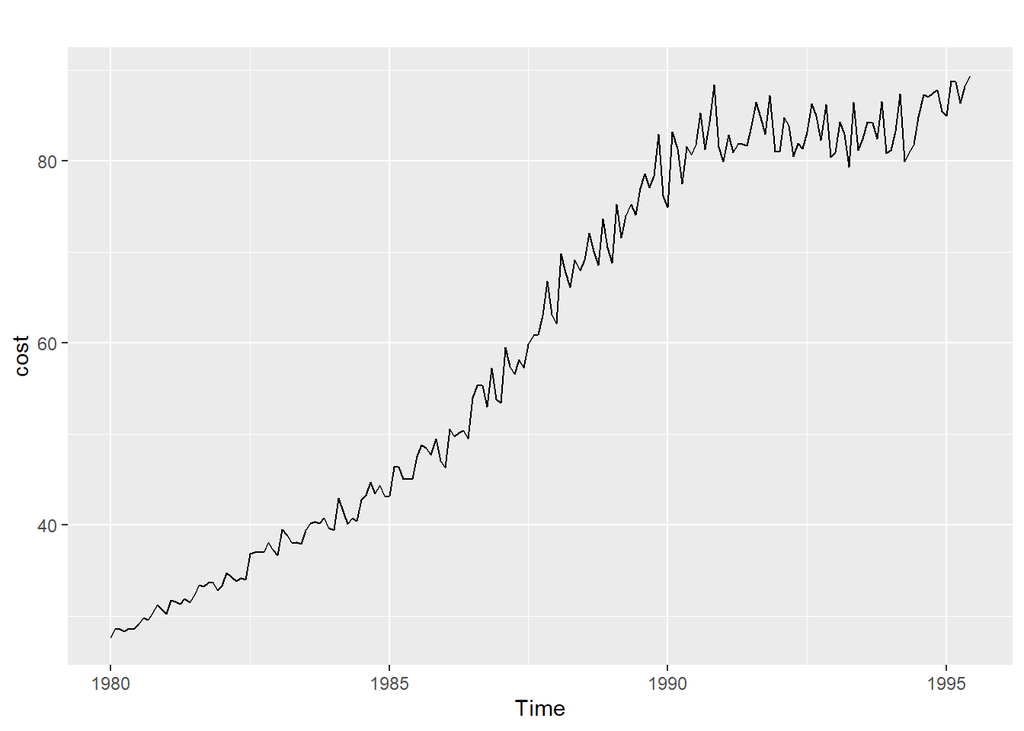

```r
setwd('C:/Users/Richa/Desktop/TS/week7/')
load("motel.rda")
roomnights <- ts(motel[,1], start = 1980, frequency = 12)
takings <- ts(motel[,2]*1000, start = 1980, frequency = 12)
cpi <- ts(motel[,3], start = 1980, frequency = 12)
cost <- takings / roomnights
autoplot(cost)
```

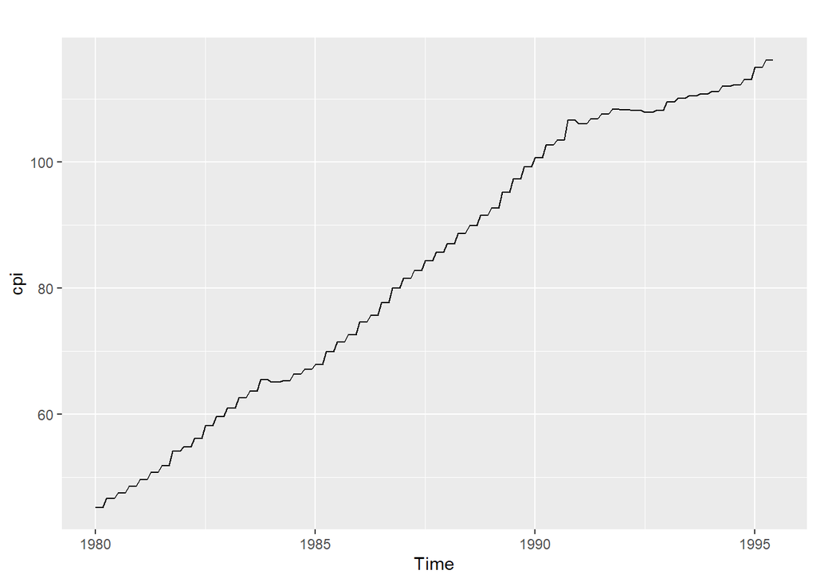

```r
autoplot(cpi)
```

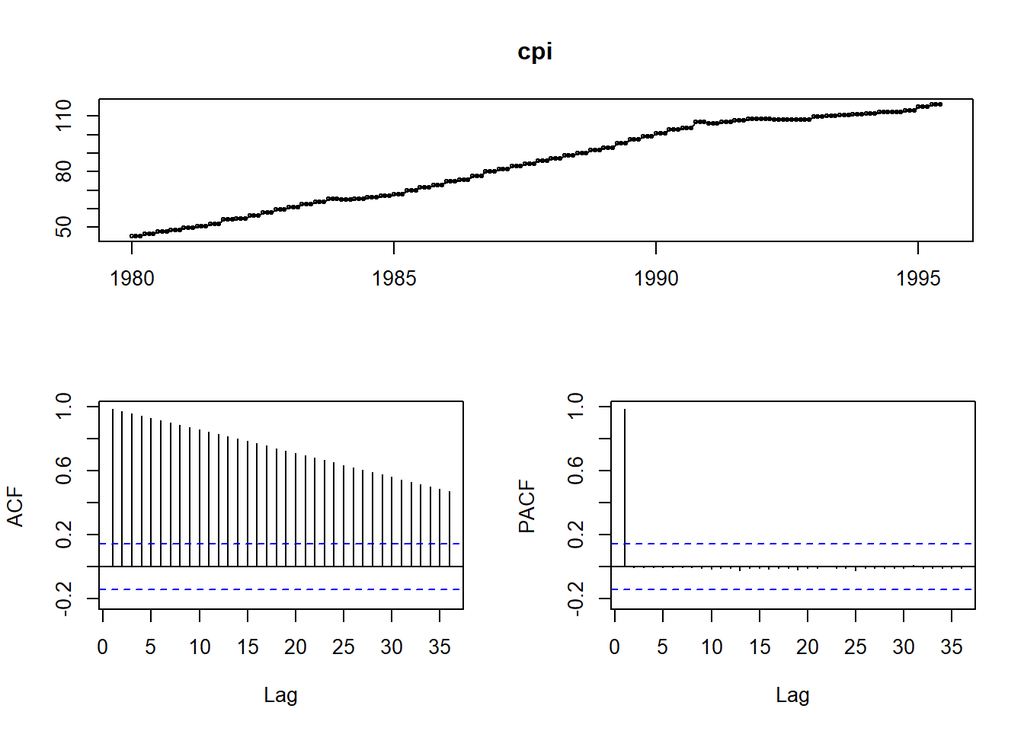

```r
tsdisplay(cpi)
```

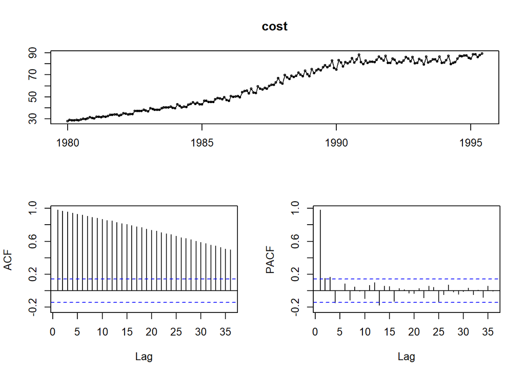

```r
tsdisplay(cost)
```

2. Plot the Cost time series against the CPI time series and calculate the correlation between CPI and Cost. Discuss your results and explain why the logarithms of both variables need to be taken before fitting any models.

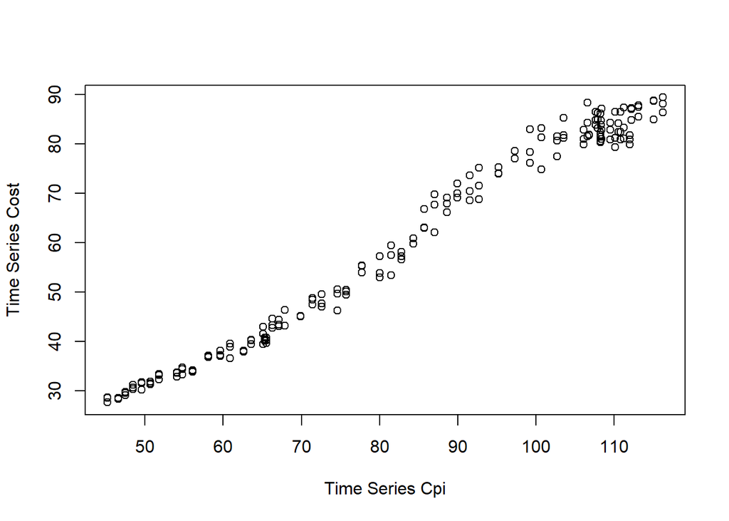

```r
plot(cpi, cost, xlab="Time Series Cpi", ylab="Time Series Cost")
```

```r
cor(cpi,cost)
```

```
## [1] 0.9907186
```

The correlation between cpi and cost is 0.9907186

Based on the visual representation of the time series data, it’s apparent that the fluctuations in the variables are not constant and evolve as the mean values change. This means the variance of both CPI and Cost is not steady. Therefore, we require a logarithmic transformation of the CPI and Cost data to make their variance stable.

3. Plot the 𝑙𝑜𝑔(𝐶𝑃𝐼) and 𝑙𝑜𝑔(𝐶𝑜𝑠𝑡) time series and calculate the correlation between the logarithms of both CPI and Cost.

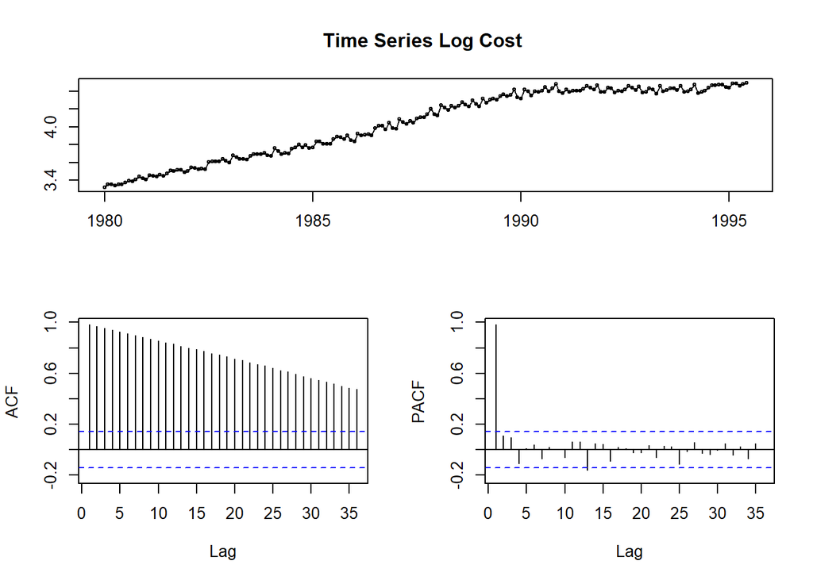

```r
log_cost = log(cost)
tsdisplay(log_cost, main = "Time Series Log Cost ")
```

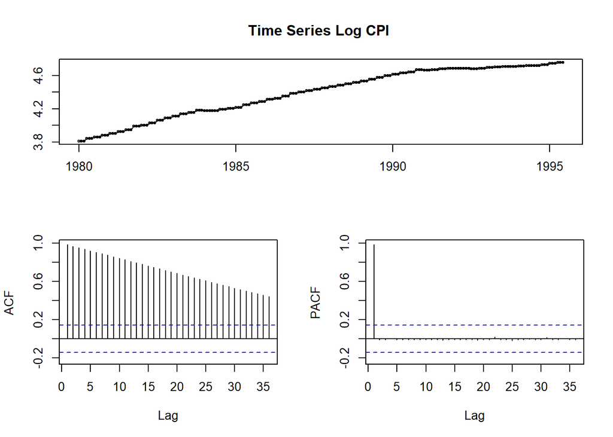

```r
log_cpi = log(cpi)
tsdisplay(log_cpi, main = "Time Series Log CPI ")
```

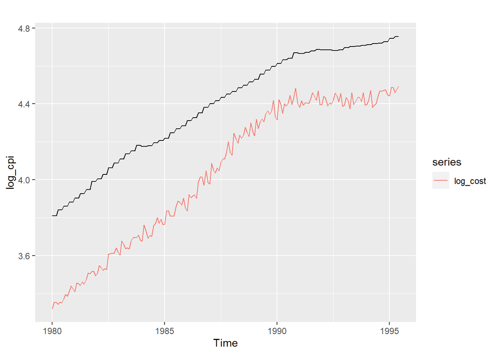

```r
autoplot(log_cpi) + autolayer(log_cost)
```

```r
cor(log_cost, log_cpi)
```

```
## [1] 0.9929902
```

## Question 2:

1. Use the linear model with time series components function tslm() to fit a linear model to the 𝑙𝑜𝑔(𝐶𝑜𝑠𝑡) time series as a function of the 𝑙𝑜𝑔(𝐶𝑃𝐼) time series (i.e., CPI ➔ Independent variable, Cost➔ Dependent variable).

```r
model_tslm = tslm(log_cost ~ log_cpi)
```

2. Plot 𝑙𝑜𝑔(𝐶𝑃𝐼) against 𝑙𝑜𝑔(𝐶𝑜𝑠𝑡) and the fitted trend.

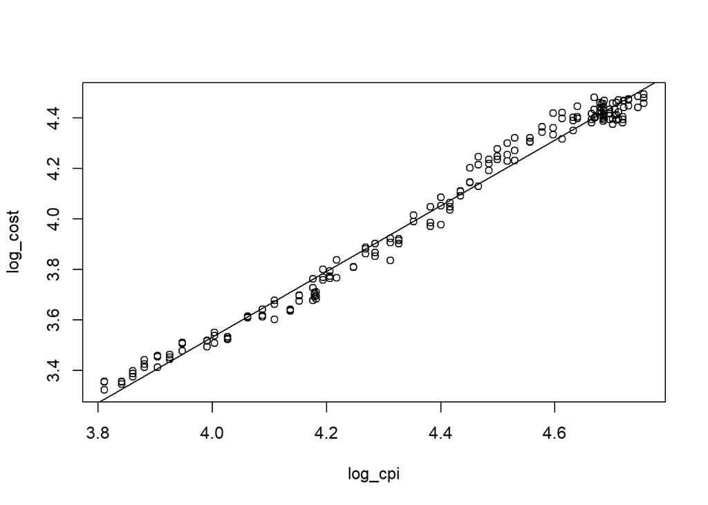

```r
plot(log_cost ~ log_cpi)
abline(model_tslm)
```

3. Use the summary() function to summarize the generated model , and the checkresiduals() function to evaluate the residuals. Discuss your results.

```r
summary(model_tslm)
```

```
##
## Call:
## tslm(formula = log_cost ~ log_cpi)
##
## Residuals:
##       Min        1Q    Median        3Q       Max
## -0.102841 -0.033939 -0.002071  0.030363  0.108670
##
## Coefficients:
##             Estimate Std. Error t value Pr(>|t|)
## (Intercept) -1.68246    0.05032  -33.44   <2e-16 ***
## log_cpi      1.30339    0.01144  113.96   <2e-16 ***
## ---
## Signif. codes:  0 '***' 0.001 '**' 0.01 '*' 0.05 '.' 0.1 ' ' 1
##
## Residual standard error: 0.04487 on 184 degrees of freedom
## Multiple R-squared:  0.986,  Adjusted R-squared:  0.986
## F-statistic: 1.299e+04 on 1 and 184 DF,  p-value: < 2.2e-16
```

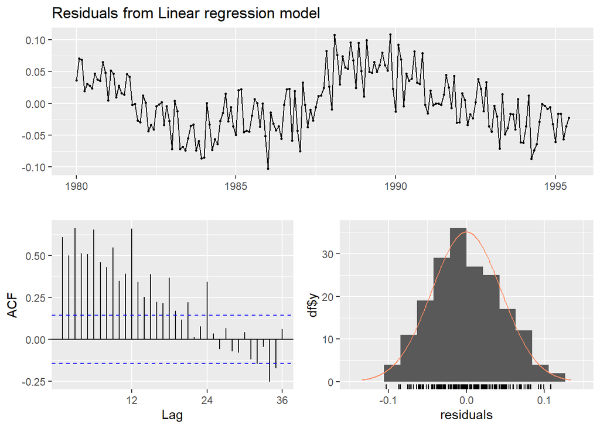

```
##
##  Breusch-Godfrey test for serial correlation of order up to 24
##
## data:  Residuals from Linear regression model
## LM test = 148.84, df = 24, p-value < 2.2e-16
```

```r
checkresiduals(model_tslm)
```

However, upon examining the ACF plot for residuals, we notice the presence of both seasonality and trend. With multiple significant lags in the residuals and a p-value less than 2.2e-16, we ascertain that the residuals are not a simple white noise. As such, the linear model incorporating time series components isn’t an optimal model in this situation.

## Question 3:

Use the auto.arima() function to fit an appropriate regression model with ARIMA errors to the Cost and CPI time series(i.e., CPI ➔ Independent variable, Cost➔ Dependent variable). Set the Order of seasonaldifferencing argument, D, to 1 and the ‘lambda’ argument to 0 to reflect a logarithmic transformation. a) Use the summary() function to summarize the generated model.

```r
model_arima <- auto.arima(y=cost,xreg=cpi,D=1,lambda = 0)
summary(model_arima)
```

```
## Series: cost
## Regression with ARIMA(0,1,1)(0,1,2)[12] errors
## Box Cox transformation: lambda= 0
##
## Coefficients:
##           ma1     sma1    sma2    xreg
##       -0.5516  -0.6160  0.1374  0.0099
## s.e.   0.0602   0.0785  0.1009  0.0025
##
## sigma^2 = 0.0003728:  log likelihood = 437.07
## AIC=-864.14   AICc=-863.79   BIC=-848.38
##
## Training set error measures:
##                       ME     RMSE       MAE        MPE     MAPE      MASE
## Training set -0.08012207 1.307136 0.8968091 -0.1126491 1.349787 0.2115032
##                     ACF1
## Training set -0.06269298
```

2. Use the checkresiduals() function to evaluate the residuals. Discuss your results.

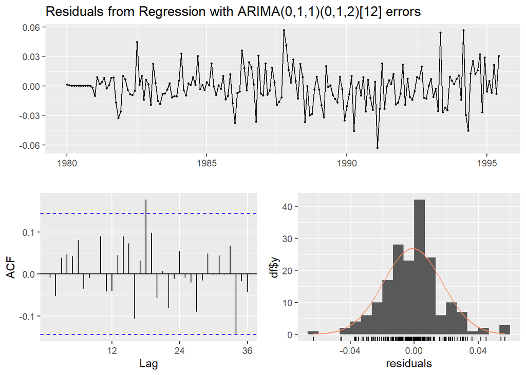

```
##
##  Ljung-Box test
##
## data:  Residuals from Regression with ARIMA(0,1,1)(0,1,2)[12] errors
## Q* = 22.342, df = 21, p-value = 0.3801
##
## Model df: 3.   Total lags used: 24
```

```r
checkresiduals(model_arima)
```

## Question 4:

1. Calculate and plot a naïve forecast of CPI for the next 18 months.

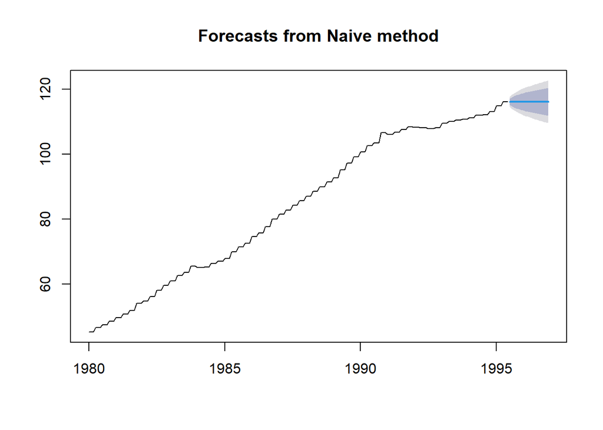

```r
naive_cpi <- naive(cpi, h = 18)
plot(naive_cpi)
```

2. Forecast and plot the average price per room (i.e., Cost) for the next 18 months using the fitted model from Question 3 and the naïve forecast of CPI. Discuss your results.

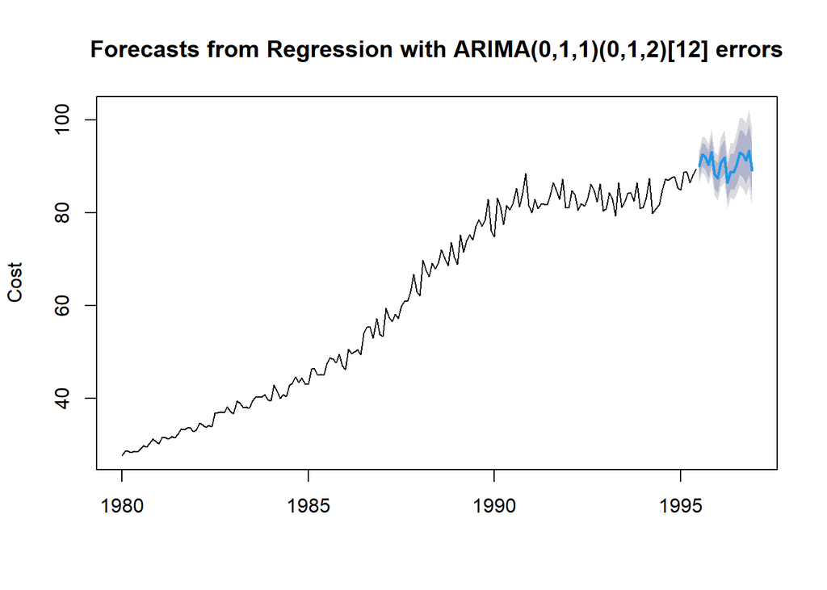

```r
arima_forcasted <- forecast(model_arima, h = 18, xreg = naive_cpi$mean)
plot(arima_forcasted, ylab = 'Cost')
```

Using naive forecasting, we’ve assumed future CPI values remain constant for the next 18 months, which isn’t always the best method as CPI may vary. However, our prediction of cost for the next 18 months, using the regression model with ARIMA and these CPI forecasts, takes into account the correlation between the variables and thus should provide better forecasts than simply using an ARIMA model alone.

## Question 5:

1. Use the VAR() function to fit a VAR(10) model to the 𝑙𝑜𝑔(𝐶𝑜𝑠𝑡) and 𝑙𝑜𝑔(𝐶𝑃𝐼) time series. Set the ‘type’ and ‘season’ arguments to ‘both’ and 12, respectively.

```r
varmodel <- VAR(cbind(log_cost,log_cpi), p = 10, type = "both", season = 12)
summary(varmodel)
```

```
##
## VAR Estimation Results:
## =========================
## Endogenous variables: log_cost, log_cpi
## Deterministic variables: both
## Sample size: 176
## Log Likelihood: 1185.453
## Roots of the characteristic polynomial:
## 0.9752 0.9588 0.9588 0.9494 0.9494 0.8857 0.8857 0.8607 0.8607 0.858 0.858 0.7962 0.7962 0.7867 0.7765 0.7765 0.7244 0.7244 0.4201 0.4201
## Call:
## VAR(y = cbind(log_cost, log_cpi), p = 10, type = "both", season = 12L)
##
##
## Estimation results for equation log_cost:
## =========================================
## log_cost = log_cost.l1 + log_cpi.l1 + log_cost.l2 + log_cpi.l2 + log_cost.l3 + log_cpi.l3 + log_cost.l4 + log_cpi.l4 + log_cost.l5 + log_cpi.l5 + log_cost.l6 + log_cpi.l6 + log_cost.l7 + log_cpi.l7 + log_cost.l8 + log_cpi.l8 + log_cost.l9 + log_cpi.l9 + log_cost.l10 + log_cpi.l10 + const + trend …
##
##                Estimate Std. Error t value Pr(>|t|)
## log_cost.l1   3.918e-01  8.566e-02   4.573 1.03e-05 ***
## log_cpi.l1    3.234e-02  3.326e-01   0.097  0.92268
## log_cost.l2   2.361e-01  9.172e-02   2.574  0.01107 *
## log_cpi.l2    5.203e-01  4.448e-01   1.170  0.24403
## log_cost.l3   2.619e-01  9.295e-02   2.818  0.00552 **
## log_cpi.l3   -3.801e-01  4.452e-01  -0.854  0.39463
## log_cost.l4   6.684e-02  9.548e-02   0.700  0.48503
## log_cpi.l4    2.113e-01  4.446e-01   0.475  0.63539
## log_cost.l5   1.064e-01  9.430e-02   1.128  0.26113
## log_cpi.l5   -7.446e-01  4.443e-01  -1.676  0.09596 .
## log_cost.l6   1.080e-01  9.370e-02   1.153  0.25095
## log_cpi.l6    5.488e-01  4.524e-01   1.213  0.22715
## log_cost.l7  -4.795e-02  9.377e-02  -0.511  0.60986
## log_cpi.l7   -1.154e-02  4.533e-01  -0.025  0.97972
## log_cost.l8  -1.478e-01  9.248e-02  -1.598  0.11216
## log_cpi.l8   -5.395e-02  4.469e-01  -0.121  0.90407
## log_cost.l9  -2.313e-02  9.246e-02  -0.250  0.80285
## log_cpi.l9    2.196e-01  4.515e-01   0.486  0.62744
## log_cost.l10 -5.534e-03  8.677e-02  -0.064  0.94924
## log_cpi.l10  -2.696e-01  3.302e-01  -0.817  0.41554
## const        -9.512e-02  1.711e-01  -0.556  0.57905
## trend        -3.844e-05  1.821e-04  -0.211  0.83310
```

[output cut: 62 more lines]

```
## Residual standard error: 0.004535 on 143 degrees of freedom
## Multiple R-Squared: 0.9998,  Adjusted R-squared: 0.9997
## F-statistic: 1.855e+04 on 32 and 143 DF,  p-value: < 2.2e-16
##
##
##
## Covariance matrix of residuals:
##           log_cost   log_cpi
## log_cost 3.704e-04 1.699e-05
## log_cpi  1.699e-05 2.057e-05
##
## Correlation matrix of residuals:
##          log_cost log_cpi
## log_cost   1.0000  0.1947
## log_cpi    0.1947  1.0000
```

```r
VARselect(cbind(log_cost, log_cpi), lag.max = 10, type="trend")$selection
```

```
## AIC(n)  HQ(n)  SC(n) FPE(n)
##     10      7      7     10
```

```r
serial.test(varmodel, lags.pt = 10, type = 'PT.asymptotic')
```

```
##
##  Portmanteau Test (asymptotic)
##
## data:  Residuals of VAR object varmodel
## Chi-squared = 5.8494, df = 0, p-value < 2.2e-16
```

2. Forecast and plot the average price per room (i.e., Cost) and CPI for the next 18 months using your fitted model.

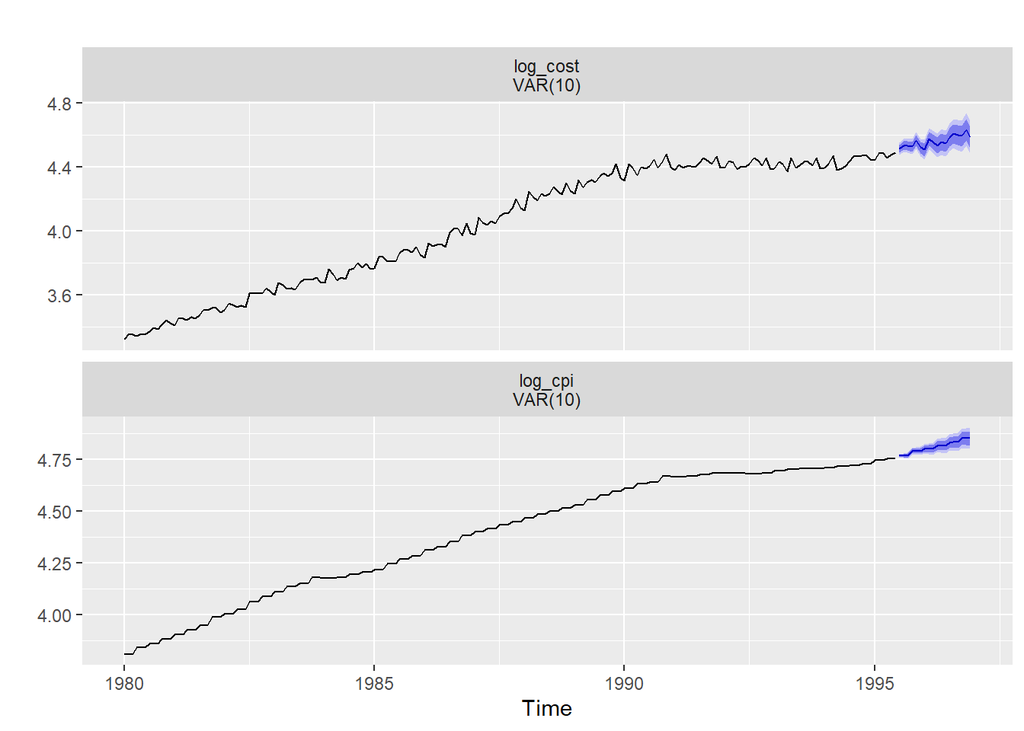

```r
varforcast <- forecast(varmodel, h = 18)
autoplot(varforcast)
```

3. Plot the residuals’ ACF. Discuss your results

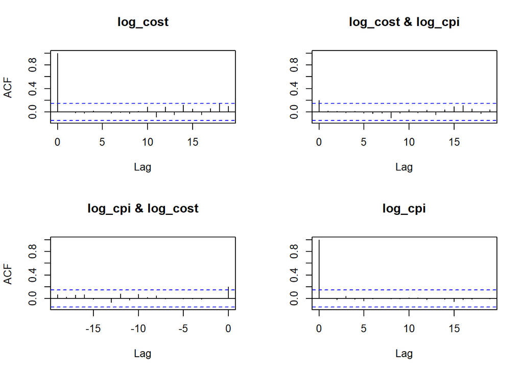

```r
acf(residuals(varmodel))
```